# Alcohol Analysis

- Show All Code
- Hide All Code
- View Source

Author

Cormac Monaghan

Published

February 27, 2024

# HRS (Alcohol Data)

The health and retirement study contains several questions related to alcohol and alcohol consumption.

- “Do you ever drink any alcoholic beverages such as beer, wine, or liquor.”
- “In the last three months, on average, how many days per week have you had any alcohol to drink? - For example, beer, wine, or any drink containing liquor.”
- “In the last three months, on the days you drink, about how many drinks do you have.”

```r
health_data %>%
  select(ID, Alcohol, Days_drink, Days_no_drink, Amount_drink) %>%
  head(n = 5) %>%
  kableExtra::kbl(align = 'c') %>%
  kableExtra::kable_styling(
    full_width = FALSE,
    bootstrap_options = c("striped", "hover", "condensed", "responsive"))
```

| ID | Alcohol | Days_drink | Days_no_drink | Amount_drink |
| --- | --- | --- | --- | --- |
| 1 | 1 | 2 | 5 | 1 |
| 2 | 0 | 0 | 7 | 0 |
| 3 | 0 | 0 | 7 | 0 |
| 4 | 0 | 0 | 7 | 0 |
| 5 | 0 | 0 | 7 | 0 |

# Exploratory Analysis

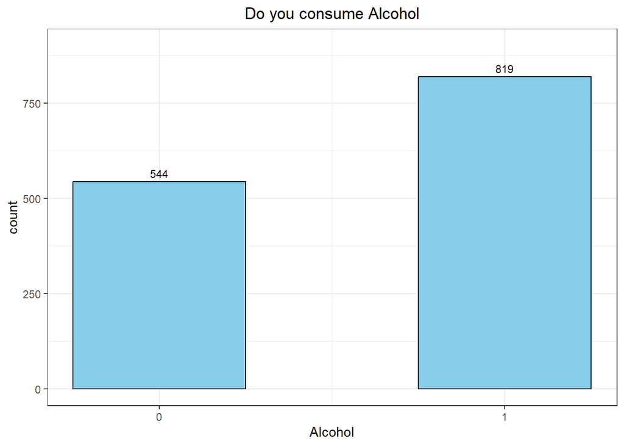

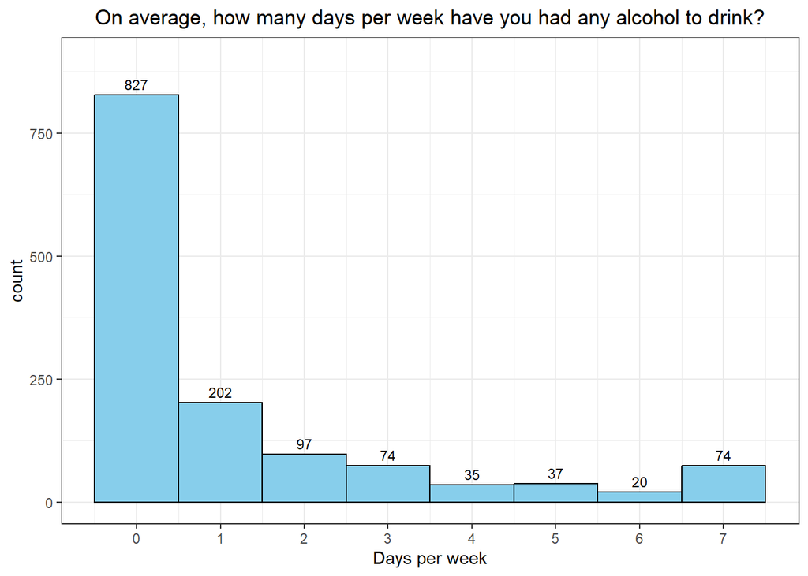

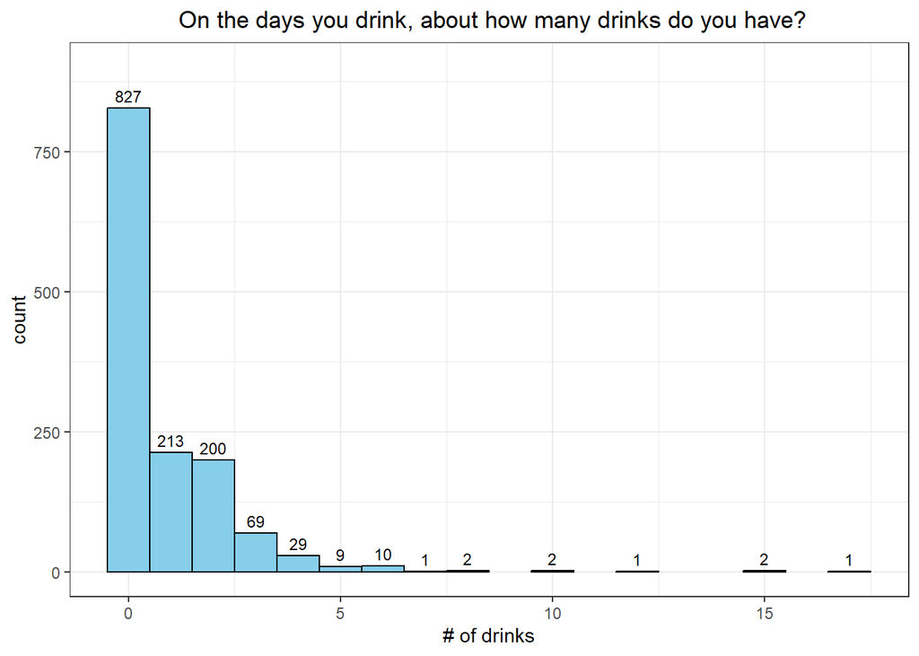

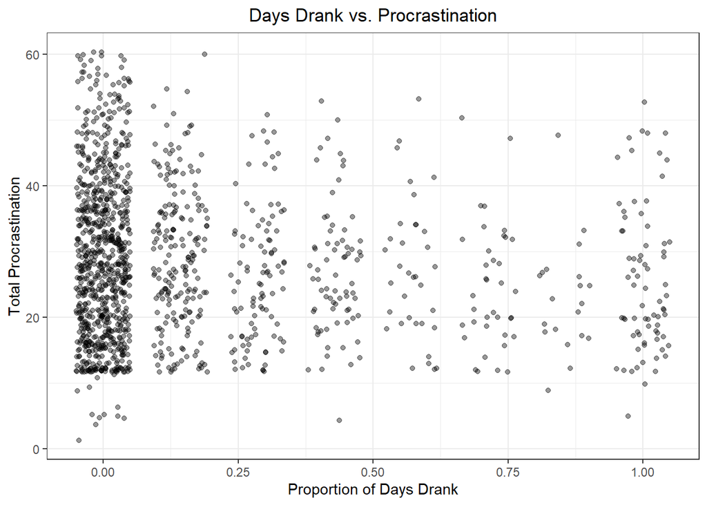

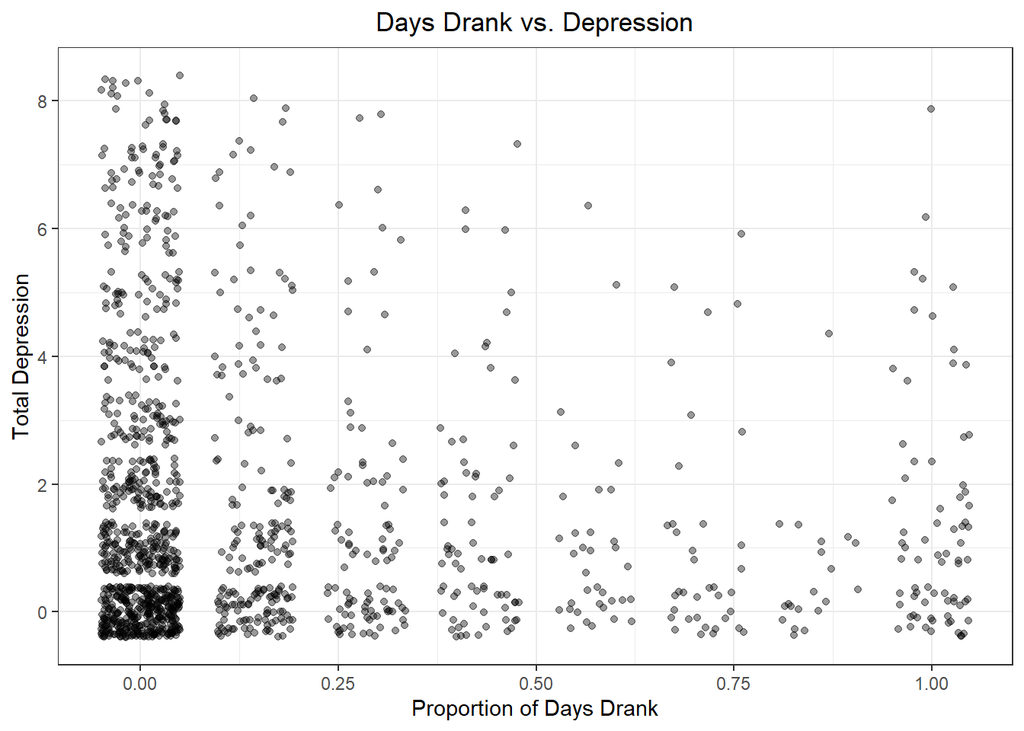

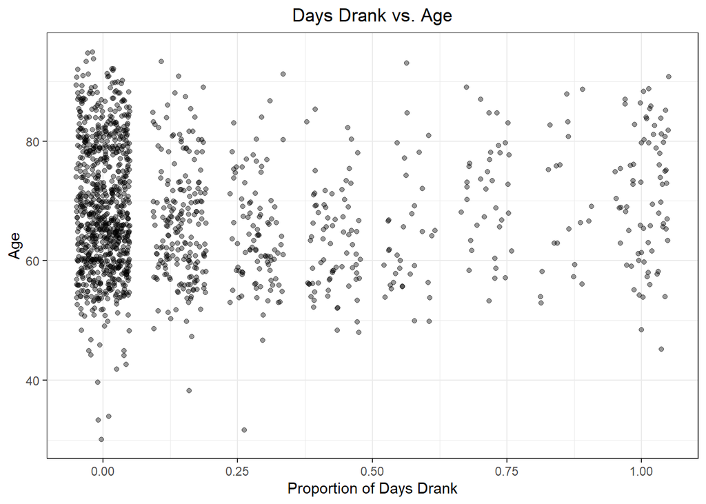

```r
# Do you drink alcohol
health_data %>%
  ggplot(aes(Alcohol)) +
  geom_bar(width = 0.5, fill = "skyblue", colour = "black") +
  stat_count(geom = "text", aes(label = ..count..), vjust = -0.5, size = 3) +
  scale_x_continuous(breaks = c(0, 1)) +
  ylim(0, 900) +
  labs(title = "Do you consume Alcohol") +
  theme_bw() +
  ggeasy::easy_center_title()

# How many days a week for you drink alcohol
health_data %>%
  ggplot(aes(Days_drink)) +
  geom_histogram(binwidth = 1, fill = "skyblue", colour = "black") +
  scale_x_continuous(breaks = seq(0, 7, by = 1)) +
  stat_count(geom = "text", aes(label = ..count..), vjust = -0.5, size = 3) +
  labs(title = "On average, how many days per week have you had any alcohol to drink?",
       x = "Days per week") +
  ylim(0, 900) +
  theme_bw() +
  ggeasy::easy_center_title()

# How much Alcohol per week do you drink
health_data %>%
  ggplot(aes(Amount_drink)) +
  geom_bar(width = 1, fill = "skyblue", colour = "black") +
  stat_count(geom = "text", aes(label = ..count..), vjust = -0.5, size = 3) +
  labs(title = " On the days you drink, about how many drinks do you have?",
       x = "# of drinks") +
  ylim(0, 900) +
  theme_bw() +
  ggeasy::easy_center_title()

# Procrastination
health_data %>%
  ggplot(aes(x = Days_drink / (Days_drink + Days_no_drink), y = Total_procrastination)) +
  geom_jitter(width = 0.05, alpha = 0.4) +
  labs(title = "Days Drank vs. Procrastination",
       x = "Proportion of Days Drank", y = "Total Procrastination") +
  theme_bw() +
  ggeasy::easy_center_title()

# Depression
health_data %>%
  ggplot(aes(x = Days_drink / (Days_drink + Days_no_drink), y = Total_depression)) +
  geom_jitter(width = 0.05, alpha = 0.4) +
  labs(title = "Days Drank vs. Depression",
       x = "Proportion of Days Drank", y = "Total Depression") +
  theme_bw() +
  ggeasy::easy_center_title()

# Age
health_data %>%
  ggplot(aes(x = Days_drink / (Days_drink + Days_no_drink), y = Age)) +
  geom_jitter(width = 0.05, alpha = 0.4) +
  labs(title = "Days Drank vs. Age",
       x = "Proportion of Days Drank", y = "Age") +
  theme_bw() +
  ggeasy::easy_center_title()
```

# Modelling

## Quadratic Binomial GLM (one predictor)

**Overview**

$$log \; \frac{p_i}{1-p_i} = \beta_0 + \beta_1x_i + \beta_2x_i^2$$
where $p_i$ is the probability of drinking on a given day for the $i$-th person, $x_i$ and $x_i^2$ are the total procrastination and total squares procrastination scores for the $i$-th person respectively, and $\beta_0$, $\beta_1$ and $\beta_2$ are the respected coefficients to be estimated.

**Model Fitting**

```r
fit_1 <- glm(cbind(Days_drink, Days_no_drink) ~ Total_procrastination + I(Total_procrastination^2),
           data = health_data, family = binomial(link = "logit"))

summary(fit_1)
```

```
Call:
glm(formula = cbind(Days_drink, Days_no_drink) ~ Total_procrastination +
    I(Total_procrastination^2), family = binomial(link = "logit"),
    data = health_data)

Coefficients:
                             Estimate Std. Error z value Pr(>|z|)
(Intercept)                -1.7377275  0.1681978 -10.331  < 2e-16 ***
Total_procrastination       0.0331647  0.0122012   2.718  0.00656 **
I(Total_procrastination^2) -0.0009022  0.0002036  -4.431 9.36e-06 ***
---
Signif. codes:  0 '***' 0.001 '**' 0.01 '*' 0.05 '.' 0.1 ' ' 1

(Dispersion parameter for binomial family taken to be 1)

    Null deviance: 5121.2  on 1358  degrees of freedom
Residual deviance: 5032.4  on 1356  degrees of freedom
  (9 observations deleted due to missingness)
AIC: 6018.2

Number of Fisher Scoring iterations: 4
```

**Diagnostics**

```
Binomial model
```

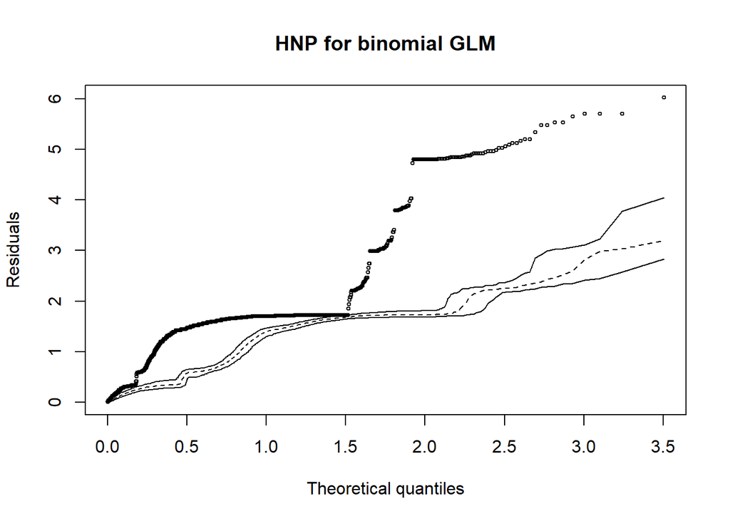

```r
# Using a half normal plot with simulated envelopes
hnp::hnp(fit_1, main = "HNP for binomial GLM")
```

**Visualizing**

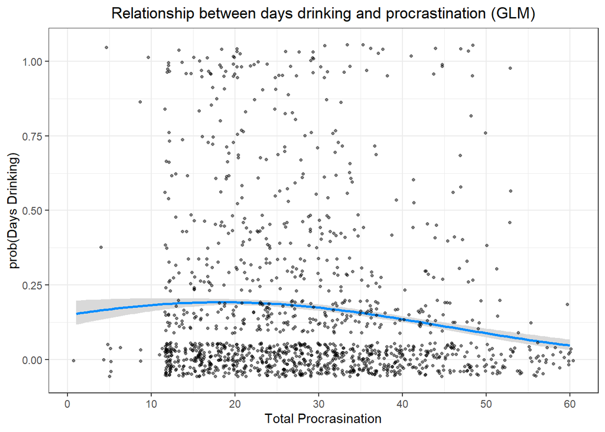

```r
visreg(fit = fit_1, xvar = "Total_procrastination", gg = TRUE,
       scale = "response", rug = FALSE) +
  geom_jitter(data = health_data, aes(x = Total_procrastination, y = Days_drink / 7),
              alpha = 0.5, size = 0.9) +
  scale_x_continuous(breaks = seq(0, 60, by = 10)) +
  labs(title = "Relationship between days drinking and procrastination (GLM)",
       x = "Total Procrasination",
       y = "prob(Days Drinking)") +
  theme_bw() +
  ggeasy::easy_center_title()
```

## Binomial GLM (multiple predictors)

**Overview**

$$log \; \frac{p_i}{1-p_i} = \beta_0 + \beta_1x_{1i} + \beta_2x_{2i} + \dots + \beta_px_{qi}$$

where $p_i$ is the probability of drinking on a given day for the $i$-th person, $\beta_0, \beta_1, \dots, \beta_p$ are the coefficients to be estimated for each independent variable, and $x_{1i}, x_{2i}, \dots, x_{qi}$ are the independent variables themselves for the $i$-th person.

**Model Fitting**

```r
fit_2 <- glm(cbind(Days_drink, Days_no_drink) ~ Total_procrastination + I(Total_procrastination^2) + Total_depression + Education + Age,
             data = health_data, family = binomial(link = "logit"))

summary(fit_2)
```

```
Call:
glm(formula = cbind(Days_drink, Days_no_drink) ~ Total_procrastination +
    I(Total_procrastination^2) + Total_depression + Education +
    Age, family = binomial(link = "logit"), data = health_data)

Coefficients:
                             Estimate Std. Error z value Pr(>|z|)
(Intercept)                -2.3182062  0.2776963  -8.348  < 2e-16 ***
Total_procrastination       0.0300580  0.0128272   2.343 0.019114 *
I(Total_procrastination^2) -0.0007473  0.0002148  -3.479 0.000503 ***
Total_depression           -0.0542998  0.0160128  -3.391 0.000696 ***
Education                   0.1904710  0.0192005   9.920  < 2e-16 ***
Age                         0.0014166  0.0027997   0.506 0.612862
---
Signif. codes:  0 '***' 0.001 '**' 0.01 '*' 0.05 '.' 0.1 ' ' 1

(Dispersion parameter for binomial family taken to be 1)

    Null deviance: 4877.6  on 1277  degrees of freedom
Residual deviance: 4659.2  on 1272  degrees of freedom
  (90 observations deleted due to missingness)
AIC: 5563.1

Number of Fisher Scoring iterations: 4
```

**Diagnostics**

```
Binomial model
```

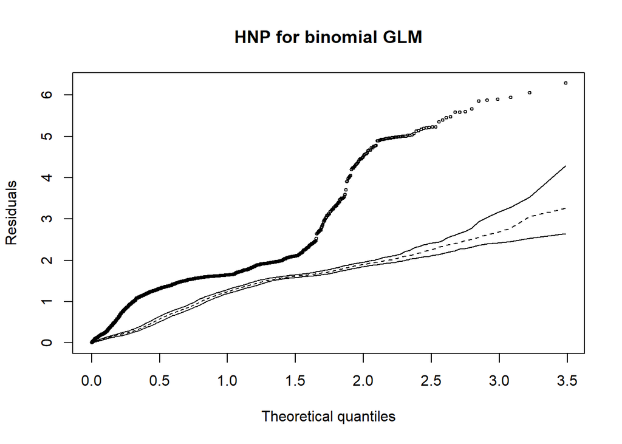

```r
# Using a half normal plot with simulated envelopes
hnp::hnp(fit_2, main = "HNP for binomial GLM")
```

**Visualizing**

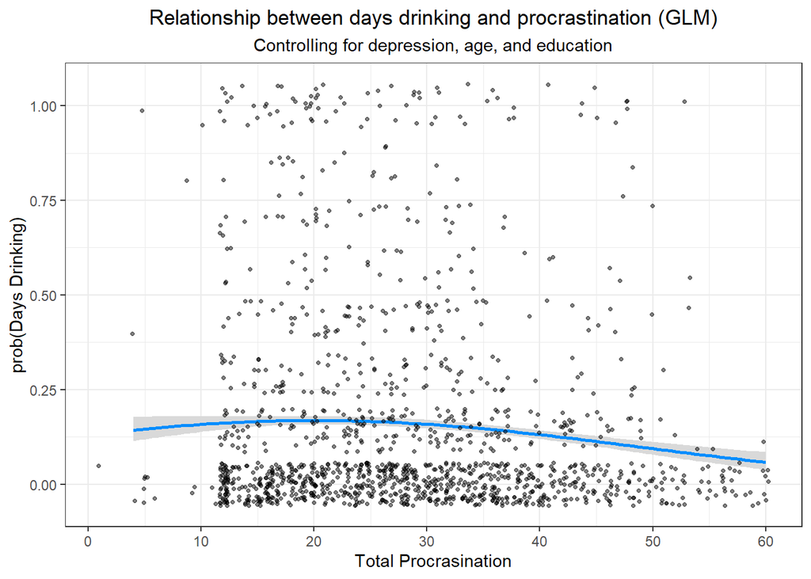

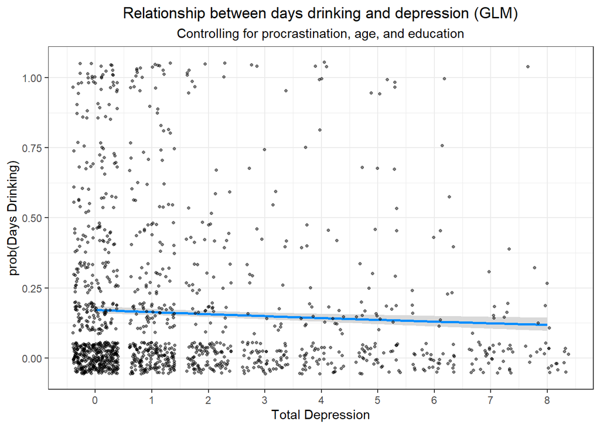

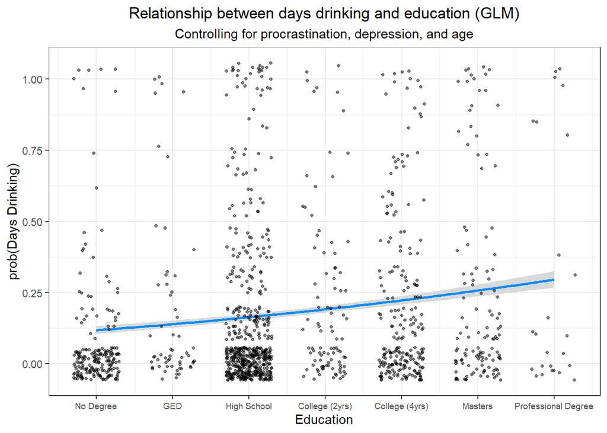

```r
# Procrastination
visreg(fit = fit_2, xvar = "Total_procrastination", gg = TRUE,
       scale = "response", rug = FALSE) +
  geom_jitter(data = health_data, aes(x = Total_procrastination, y = Days_drink / 7),
              alpha = 0.5, size = 0.9) +
  scale_x_continuous(breaks = seq(0, 60, by = 10)) +
  labs(title = "Relationship between days drinking and procrastination (GLM)",
       subtitle = "Controlling for depression, age, and education",
       x = "Total Procrasination", y = "prob(Days Drinking)") +
  theme_bw() +
  theme(plot.title = element_text(hjust = 0.5),
        plot.subtitle = element_text(hjust = 0.5))

# Depression
visreg(fit = fit_2, xvar = "Total_depression", gg = TRUE,
       scale = "response", rug = FALSE) +
  geom_jitter(data = health_data, aes(x = Total_depression, y = Days_drink / 7),
              alpha = 0.5, size = 0.9) +
  scale_x_continuous(breaks = seq(0, 8, by = 1)) +
  labs(title = "Relationship between days drinking and depression (GLM)",
       subtitle = "Controlling for procrastination, age, and education",
       x = "Total Depression", y = "prob(Days Drinking)") +
  theme_bw() +
  theme(plot.title = element_text(hjust = 0.5),
        plot.subtitle = element_text(hjust = 0.5))

# Education
visreg(fit = fit_2, xvar = "Education", gg = TRUE,
       scale = "response", rug = FALSE) +
  geom_jitter(data = health_data, aes(x = Education, y = Days_drink / 7),
              width = 0.3, alpha = 0.5, size = 0.9) +
  scale_x_continuous(breaks = seq(0, 6, by = 1), labels = c(
    "No Degree", "GED", "High School",
    "College (2yrs)", "College (4yrs)",
    "Masters", "Professional Degree")) +
  labs(title = "Relationship between days drinking and education (GLM)",
       subtitle = "Controlling for procrastination, depression, and age",
       x = "Education", y = "prob(Days Drinking)") +
  theme_bw() +
  theme(plot.title = element_text(hjust = 0.5),
        plot.subtitle = element_text(hjust = 0.5)) +
  ggeasy::easy_x_axis_labels_size(size = 7)
```

## Binomial GAM

**Overview**
$$log \; \frac{p_i}{1 - p_i} = \alpha + f_1(x_{1i}) + f_2(x_{2i}) + \dots + f_q(x_{qi})$$
where $p_i$ is the probability of drinking on a given day, $\alpha$ is the intercept term, $f_1, \dots, f_q$ are smooth function of the predictor variables $x_{1i}, \dots, x_{qi}$. The smooth functions $f_q$ can be estimated by various methods, such as splines, kernels, or local regression.

**Model Fitting**

```r
fit_3 <- gam(cbind(Days_drink, Days_no_drink) ~ s(Total_procrastination) + s(Total_depression, k = 9) + s(Age) + Education,
             data = health_data, family = "binomial", method = "REML")

summary(fit_3)
```

```
Family: binomial
Link function: logit

Formula:
cbind(Days_drink, Days_no_drink) ~ s(Total_procrastination) +
    s(Total_depression, k = 9) + s(Age) + Education

Parametric coefficients:
            Estimate Std. Error z value Pr(>|z|)
(Intercept) -2.22746    0.06206  -35.89   <2e-16 ***
Education    0.19754    0.01934   10.21   <2e-16 ***
---
Signif. codes:  0 '***' 0.001 '**' 0.01 '*' 0.05 '.' 0.1 ' ' 1

Approximate significance of smooth terms:
                           edf Ref.df Chi.sq p-value
s(Total_procrastination) 8.120  8.716 77.007  <2e-16 ***
s(Total_depression)      6.538  7.359 44.615  <2e-16 ***
s(Age)                   1.005  1.010  0.028   0.878
---
Signif. codes:  0 '***' 0.001 '**' 0.01 '*' 0.05 '.' 0.1 ' ' 1

R-sq.(adj) =  0.0471   Deviance explained = 6.98%
-REML = 2757.7  Scale est. = 1         n = 1278
```

**Diagnostics**

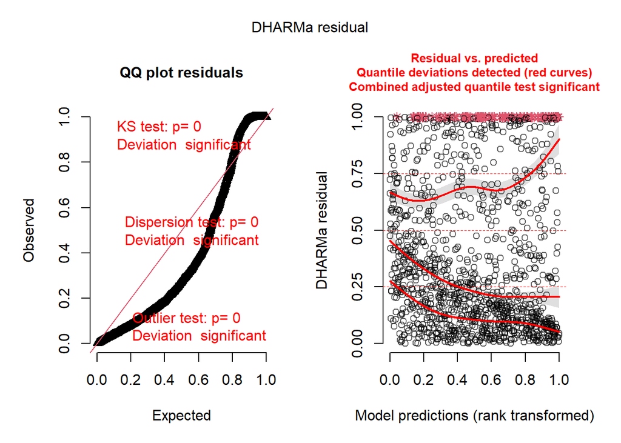

```r
fit_3_residuals <- DHARMa::simulateResiduals(fit_3)
plot(fit_3_residuals)
```

**Visualization**

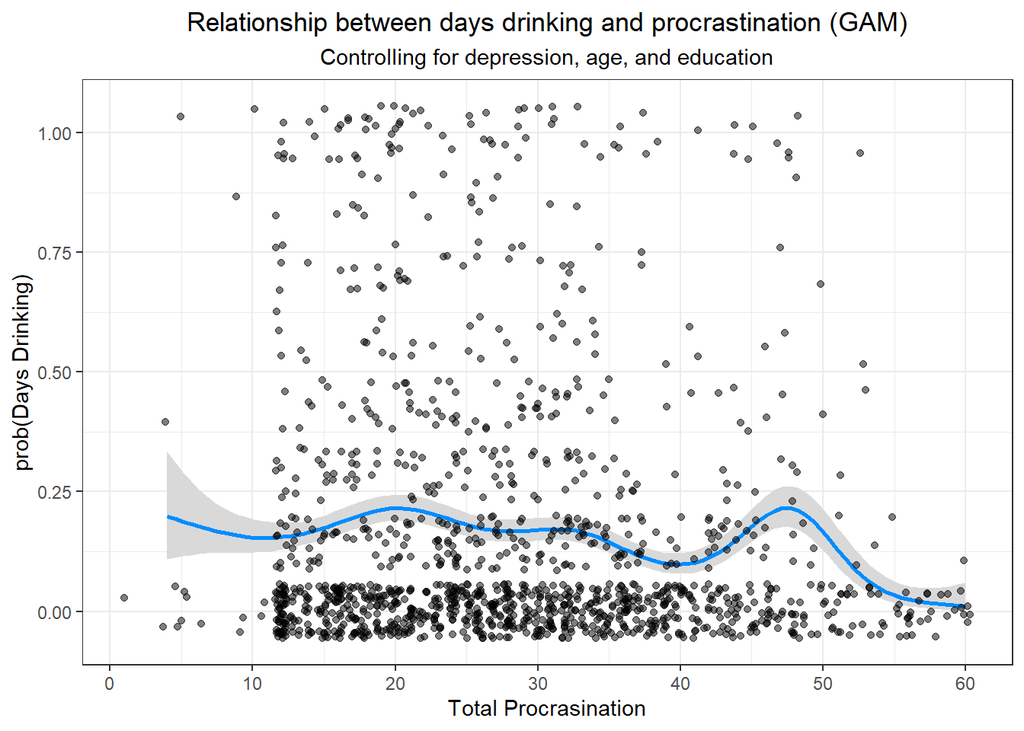

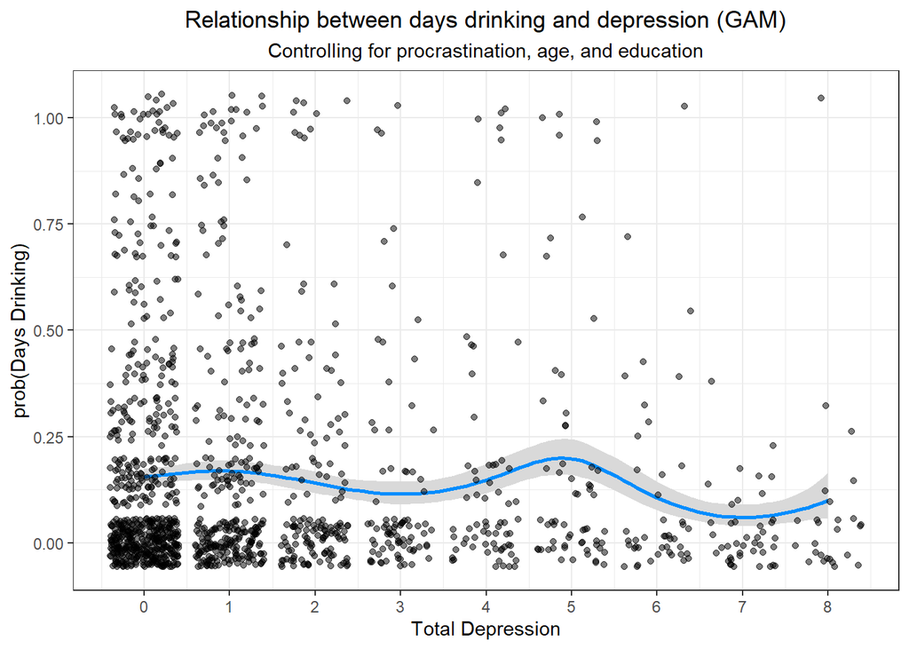

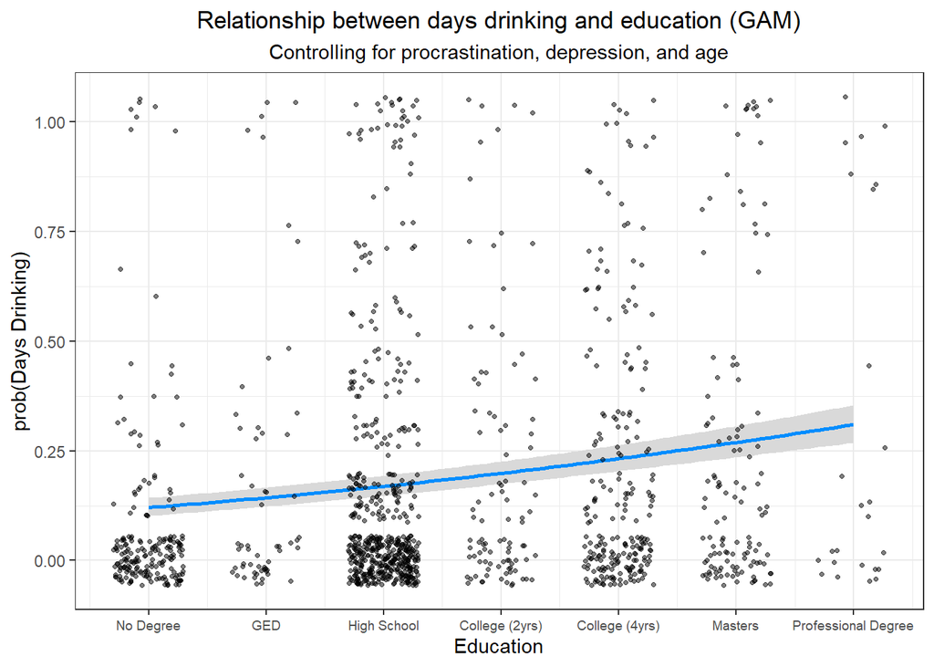

```r
# Procrastination
visreg(fit = fit_3, xvar = "Total_procrastination", gg = TRUE,
       scale = "response", rug = FALSE) +
  geom_jitter(data = health_data, aes(x = Total_procrastination, y = Days_drink / 7),
              alpha = 0.5) +
  scale_x_continuous(breaks = seq(0, 60, by = 10)) +
  labs(title = "Relationship between days drinking and procrastination (GAM)",
       subtitle = "Controlling for depression, age, and education",
       x = "Total Procrasination", y = "prob(Days Drinking)") +
  theme_bw() +
  theme(plot.title = element_text(hjust = 0.5),
        plot.subtitle = element_text(hjust = 0.5))

# Depression
visreg(fit = fit_3, xvar = "Total_depression", gg = TRUE,
       scale = "response", rug = FALSE) +
  geom_jitter(data = health_data, aes(x = Total_depression, y = Days_drink / 7),
              alpha = 0.5) +
  scale_x_continuous(breaks = seq(0, 8, by = 1)) +
  labs(title = "Relationship between days drinking and depression (GAM)",
       subtitle = "Controlling for procrastination, age, and education",
       x = "Total Depression", y = "prob(Days Drinking)") +
  theme_bw() +
  theme(plot.title = element_text(hjust = 0.5),
        plot.subtitle = element_text(hjust = 0.5))

# Education
visreg(fit = fit_3, xvar = "Education", gg = TRUE,
       scale = "response", rug = FALSE) +
  geom_jitter(data = health_data, aes(x = Education, y = Days_drink / 7),
              width = 0.3, alpha = 0.5, size = 0.9) +
  scale_x_continuous(breaks = seq(0, 6, by = 1), labels = c(
    "No Degree", "GED", "High School",
    "College (2yrs)", "College (4yrs)",
    "Masters", "Professional Degree")) +
  labs(title = "Relationship between days drinking and education (GAM)",
       subtitle = "Controlling for procrastination, depression, and age",
       x = "Education", y = "prob(Days Drinking)") +
  theme_bw() +
  theme(plot.title = element_text(hjust = 0.5),
        plot.subtitle = element_text(hjust = 0.5)) +
  ggeasy::easy_x_axis_labels_size(size = 7)

# plot(fit_3, select = 1, trans = plogis, shift = fit_3$coefficients[1], seWithMean = TRUE,
#      rug = FALSE, shade = TRUE, shade.col = "skyblue",
#      ylab = "Probability", xlab = "Total Procrastination",
#      main = "Probability of drinking on a given day by procrastination")
#
# plot(fit_3, select = 2, trans = plogis, shift = fit_3$coefficients[1], seWithMean = TRUE,
#      rug = FALSE, shade = TRUE, shade.col = "skyblue",
#      ylab = "Probability", xlab = "Total Depression",
#      main = "Probability of drinking on a given day by depression")
#
# plot(fit_3, select = 3, trans = plogis, shift = fit_3$coefficients[1], seWithMean = TRUE,
#      rug = FALSE, shade = TRUE, shade.col = "skyblue",
#      ylab = "Probability", xlab = "Age",
#      main = "Probability of drinking on a given day by age")
```